# R Notebook

## Common Plot Types

There are many geoms, and they can take different arguments to customise their appearance. We’ll learn about some of the most common below.

### Bar plot

Bar plots are good for categorical data where you want to represent the count.

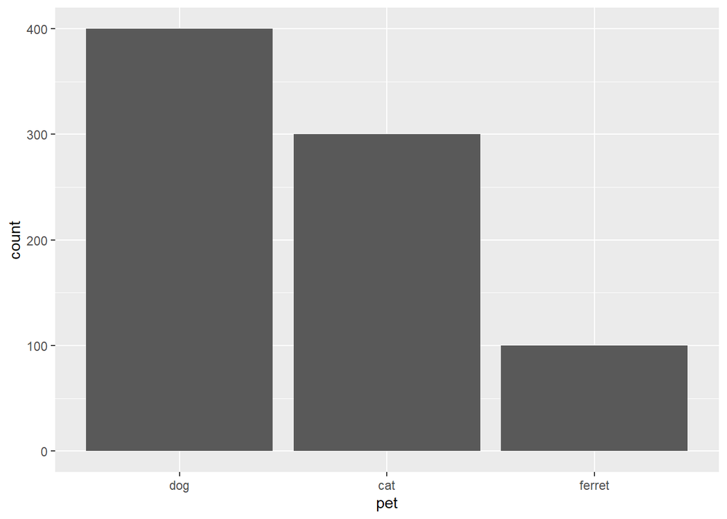

Bar plot

```r
ggplot(pets, aes(pet)) +
  geom_bar()
```

### Density plot

Density plots are good for one continuous variable, but only if you have a fairly large number of observations.

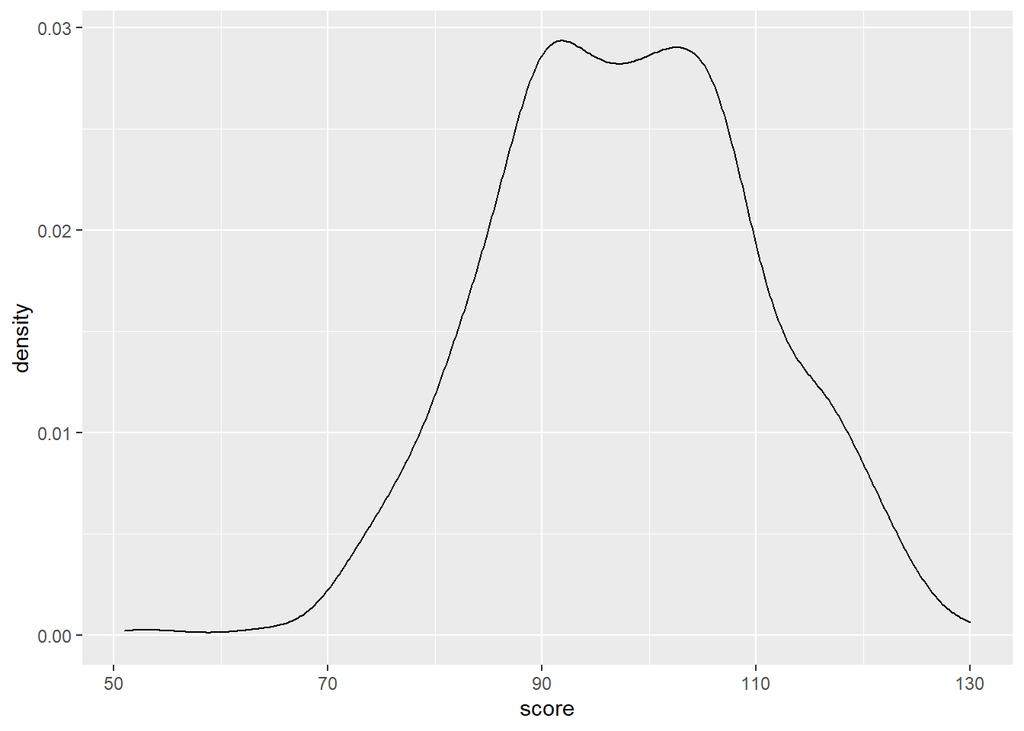

Density plot

```r
ggplot(pets, aes(score)) +
  geom_density()
```

You can represent subsets of a variable by assigning the category variable to the argument `group`, `fill`, or `color`.

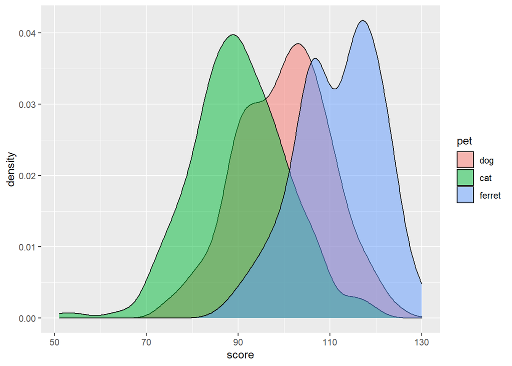

Grouped density plot

```r
ggplot(pets, aes(score, fill = pet)) +
  geom_density(alpha = 0.5)
```

Try changing the `alpha` argument to figure out what it does.

### Frequency polygons

If you want the y-axis to represent count rather than density, try `geom_freqpoly()`.

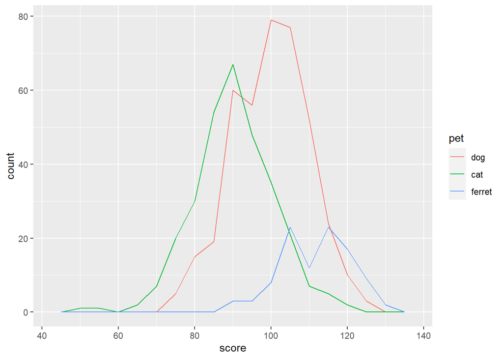

Frequency ploygon plot

```r
ggplot(pets, aes(score, color = pet)) +
  geom_freqpoly(binwidth = 5)
```

Try changing the `binwidth` argument to 10 and 1. How do you figure out the right value?

### Histogram

Histograms are also good for one continuous variable, and work well if you don’t have many observations. Set the `binwidth` to control how wide each bar is.

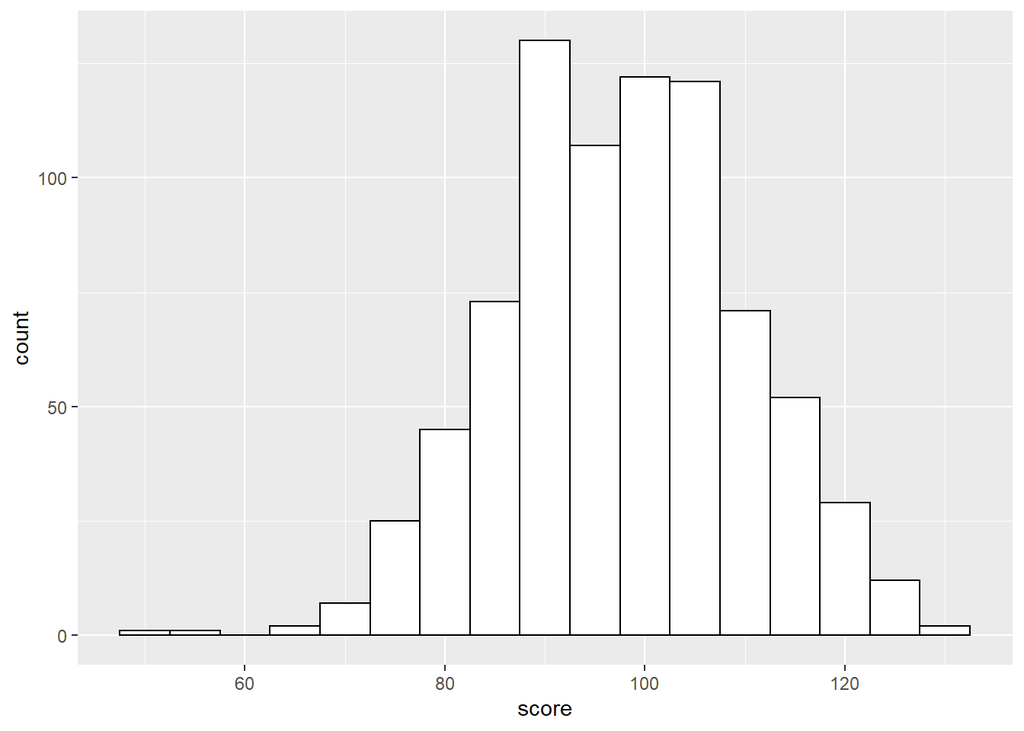

Histogram

```r
ggplot(pets, aes(score)) +
  geom_histogram(binwidth = 5, fill = "white", color = "black")
```

Histograms in ggplot look pretty bad unless you set the `fill` and `color`.

If you show grouped histograms, you also probably want to change the default `position` argument.

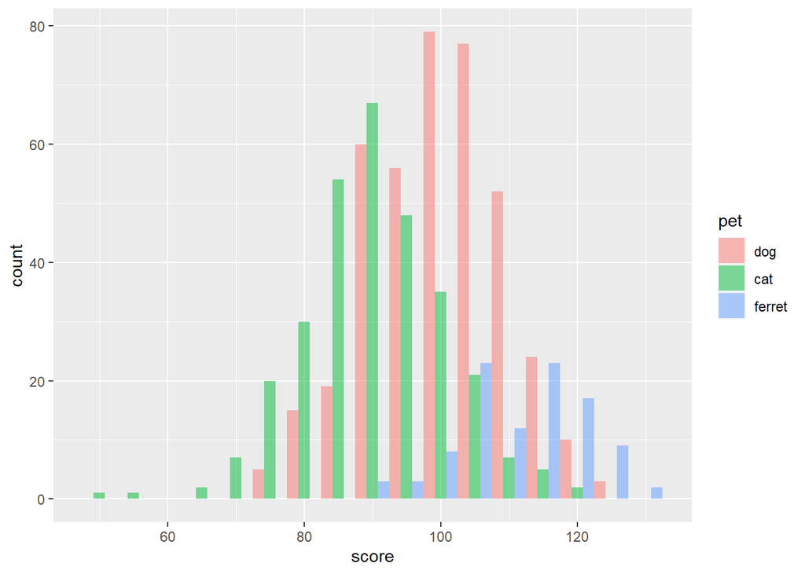

Grouped Histogram

```r
ggplot(pets, aes(score, fill=pet)) +
  geom_histogram(binwidth = 5, alpha = 0.5,
                 position = "dodge")
```

Try changing the `position` argument to “identity”, “fill”, “dodge”, or “stack”.

### Column plot

Column plots are the worst way to represent grouped continuous data, but also one of the most common. If your data are already aggregated (e.g., you have rows for each group with columns for the mean and standard error), you can use `geom_bar` or `geom_col` and `geom_errorbar` directly. If not, you can use the function `stat_summary` to calculate the mean and standard error and send those numbers to the appropriate geom for plotting.

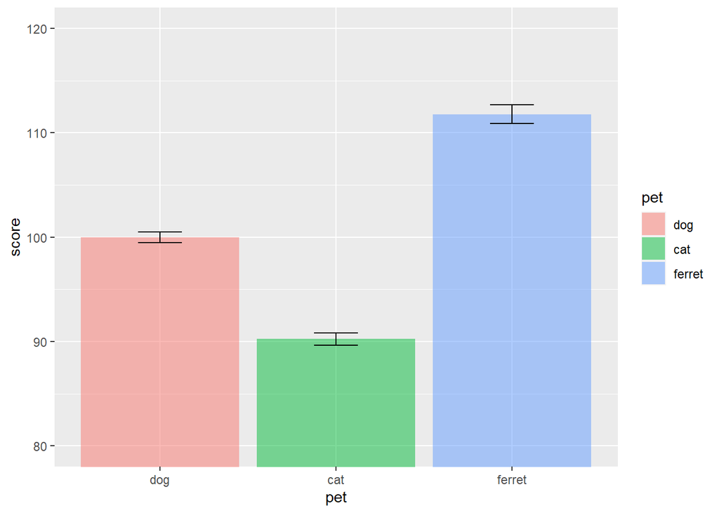

Column plot

```r
ggplot(pets, aes(pet, score, fill=pet)) +
  stat_summary(fun = mean, geom = "col", alpha = 0.5) +
  stat_summary(fun.data = mean_se, geom = "errorbar",
               width = 0.25) +
  coord_cartesian(ylim = c(80, 120))
```

Try changing the values for `coord_cartesian`. What does this do?

### Boxplot

Boxplots are great for representing the distribution of grouped continuous variables. They fix most of the problems with using bar/column plots for continuous data.

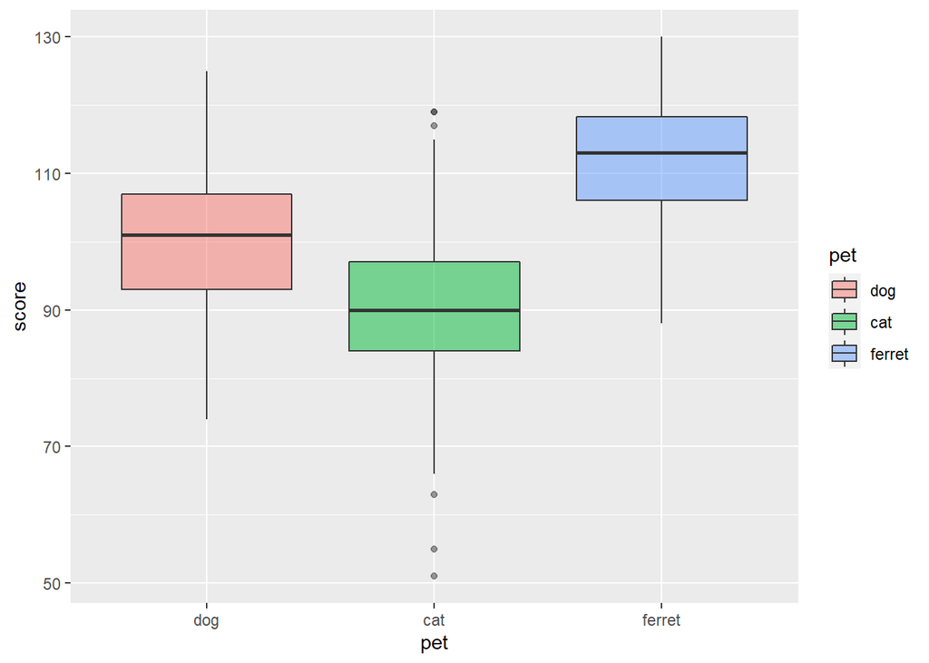

Box plot

```r
ggplot(pets, aes(pet, score, fill=pet)) +
  geom_boxplot(alpha = 0.5)
```

### Violin plot

Violin pots are like sideways, mirrored density plots. They give even more information than a boxplot about distribution and are especially useful when you have non-normal distributions.

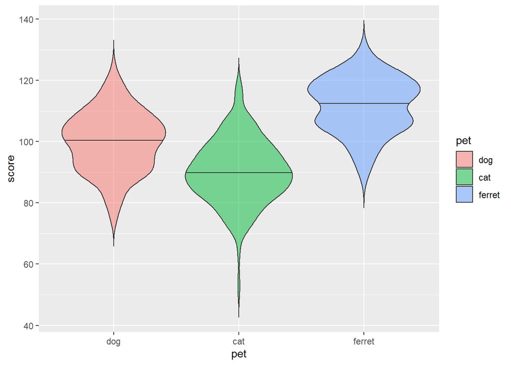

Violin plot

```r
ggplot(pets, aes(pet, score, fill=pet)) +
  geom_violin(draw_quantiles = .5,
              trim = FALSE, alpha = 0.5,)
```

Try changing the `quantile` argument. Set it to a vector of the numbers 0.1 to 0.9 in steps of 0.1.

### Scatter plot

Scatter plots are a good way to represent the relationship between two continuous variables.

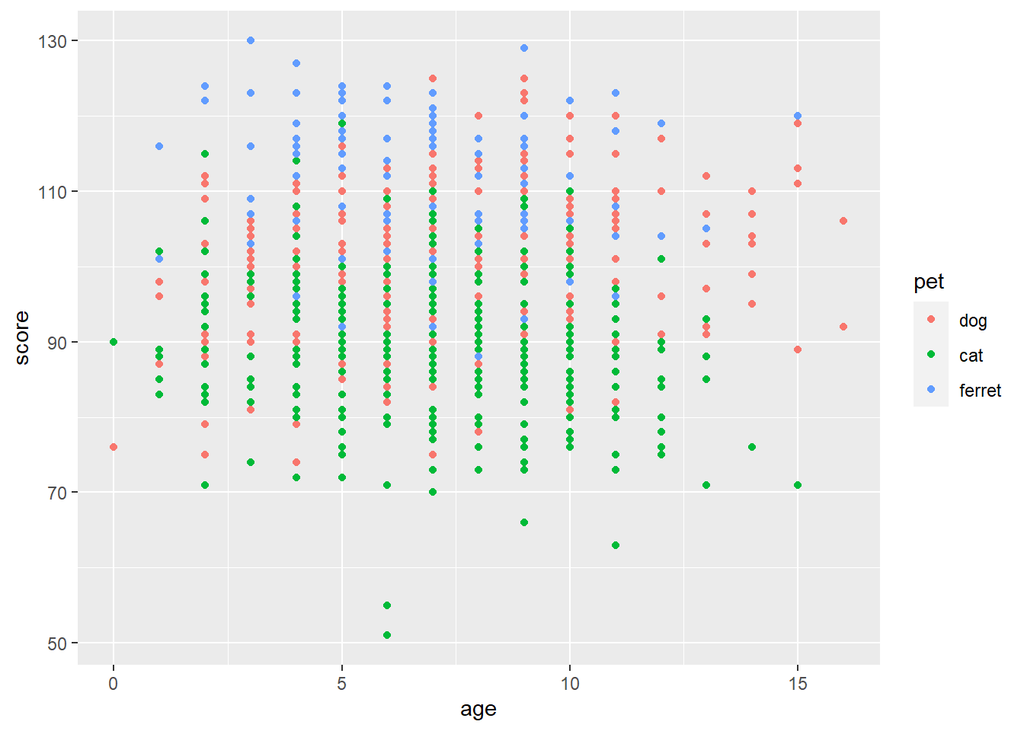

Scatter plot using geom_point()

```r
ggplot(pets, aes(age, score, color = pet)) +
  geom_point()
```

### Line graph

You often want to represent the relationship as a single line.

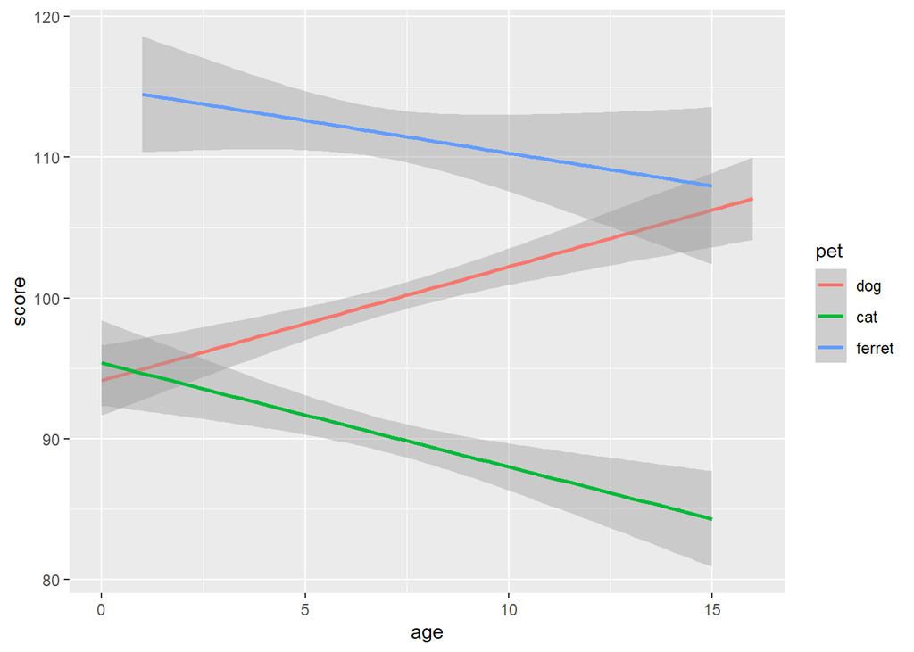

Line plot using geom_smooth()

```r
ggplot(pets, aes(age, score, color = pet)) +
  geom_smooth(formula = y ~ x, method="lm")
```

What are some other options for the `method` argument to `geom_smooth`? When might you want to use them?

You can plot functions other than the linear `y ~ x`. The code below creates a data table where `x` is 101 values between -10 and 10. and `y` is `x` squared plus `3*x` plus `1`. You’ll probably recognise this from algebra as the quadratic equation. You can set the `formula` argument in `geom_smooth` to a quadratic formula (`y ~ x + I(x^2)`) to fit a quadratic function to the data.

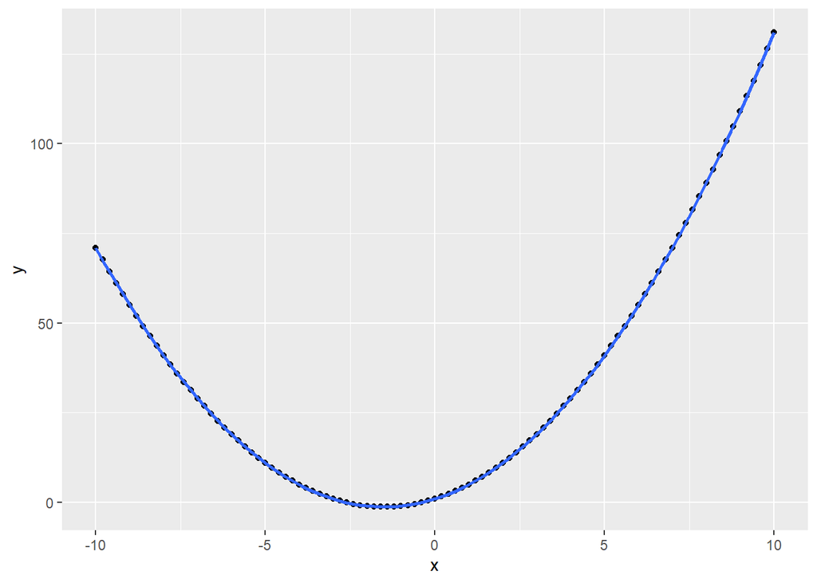

Fitting quadratic functions

```r
quad <- tibble(
  x = seq(-10, 10, length.out = 101),
  y = x^2 + 3*x + 1
)
ggplot(quad, aes(x, y)) +
  geom_point() +
  geom_smooth(formula = y ~ x + I(x^2),
              method="lm")
```

## Customisation

### Size and Position

You can change the size, aspect ratio and position of plots in an R Markdown document in the setup chunk.

```r
knitr::opts_chunk$set(
  fig.width  = 8, # figures default to 8 inches wide
  fig.height = 5, # figures default to 5 inches tall
  fig.path   = 'images/', # figures saved in images directory
  out.width = "90%", # images take up 90% of page width
  fig.align = 'center' # centre images
)
```

You can change defaults for any single image using chunk options.

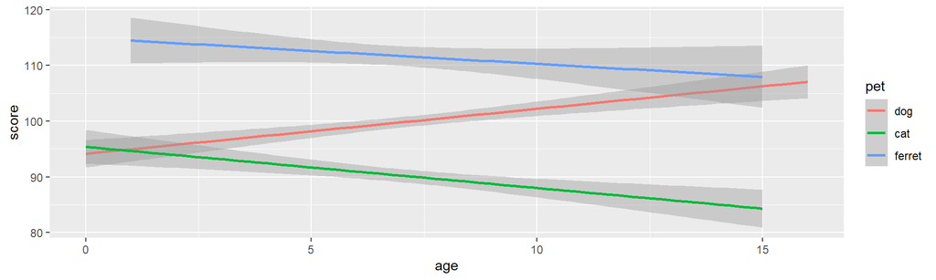

10x3 inches at 100% width centre aligned.

```r
ggplot(pets, aes(age, score, color = pet)) +
  geom_smooth(formula = y~x, method = lm)
```

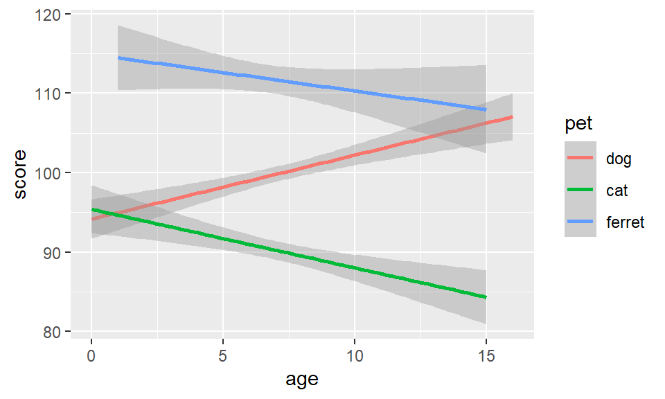

5x3 inches at 50% width aligned left.

```r
ggplot(pets, aes(age, score, color = pet)) +
  geom_smooth(formula = y~x, method = lm)
```

### Labels

You can set custom titles and axis labels in a few different ways.

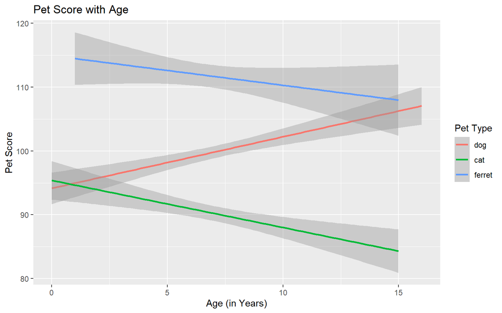

Set custom labels with labs()

```r
ggplot(pets, aes(age, score, color = pet)) +
  geom_smooth(formula = y ~ x, method="lm") +
  labs(title = "Pet Score with Age",
       x = "Age (in Years)",
       y = "Pet Score",
       color = "Pet Type")
```

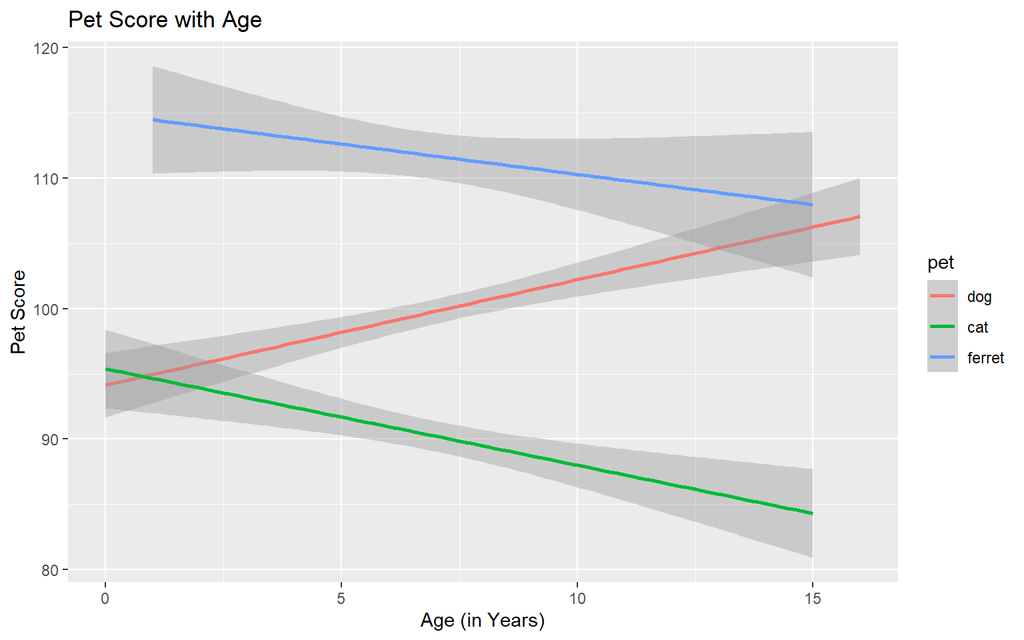

Set custom labels with individual functions

```r
ggplot(pets, aes(age, score, color = pet)) +
  geom_smooth(formula = y ~ x, method="lm") +
  ggtitle("Pet Score with Age") +
  xlab("Age (in Years)") +
  ylab("Pet Score")
```

The `scale_{aesthetic}_{type}` functions are worth learning because they let you customise many things about any aesthetic property (e.g., `x`, `y`, `colour`, `fill`, `shape`, `linetype`), as long as you choose the correct type (usually `continuous` or `discrete`, but there are also special scale functions for other data types like dates).

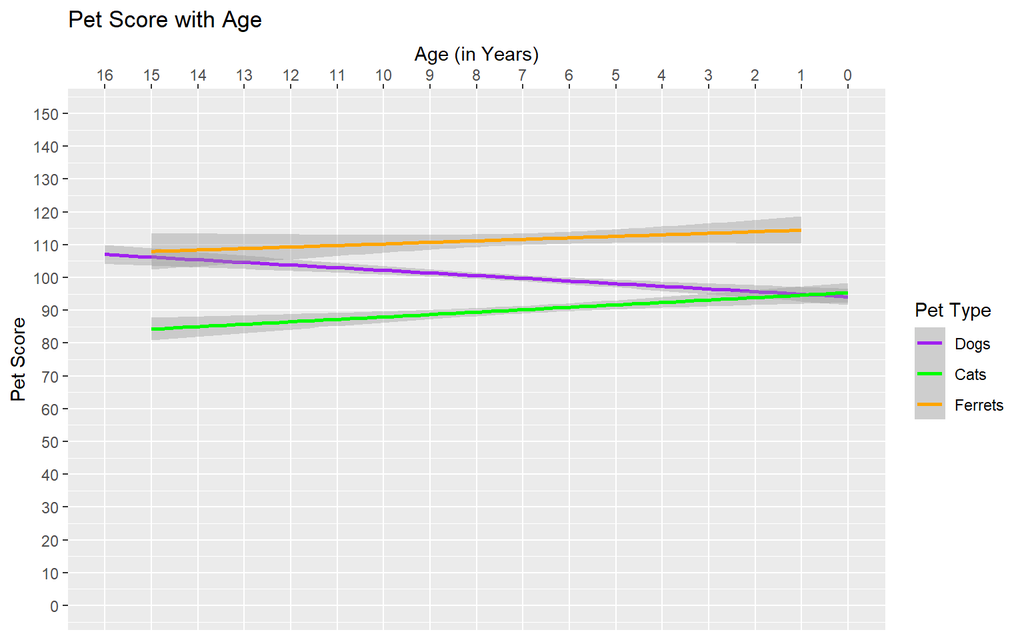

Set custom labels with scale functions

```r
ggplot(pets, aes(age, score, color = pet)) +
  geom_smooth(formula = y ~ x, method="lm") +
  ggtitle("Pet Score with Age") +
  scale_x_continuous(name = "Age (in Years)",
                     breaks = 0:16,
                     minor_breaks = NULL,
                     trans = "reverse",
                     position = "top") +
  scale_y_continuous(name = "Pet Score",
                     n.breaks = 16,
                     limits = c(0, 150)) +
  scale_color_discrete(name = "Pet Type",
                       labels = c("Dogs", "Cats", "Ferrets"),
                       type = c("purple", "green", "orange"))
```

Use the help on the scale functions above to learn about the possible arguments. See what happens when you change the arguments above.

### Colours

You can set custom values for colour and fill using the `scale_{aesthetic}_{type}` functions like `scale_colour_manual()` or `scale_fill_manual()`.

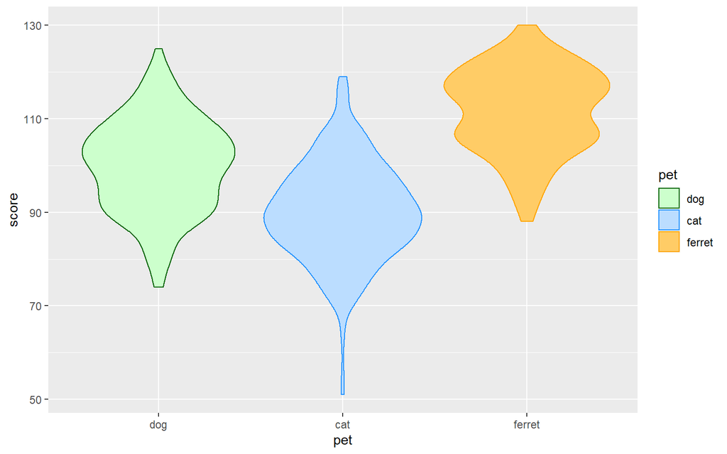

Set custom colour

```r
ggplot(pets, aes(pet, score, colour = pet, fill = pet)) +
  geom_violin() +
  scale_color_manual(values = c("darkgreen", "dodgerblue", "orange")) +
  scale_fill_manual(values = c("#CCFFCC", "#BBDDFF", "#FFCC66"))
```

The Colours chapter in Cookbook for R has many more ways to customise colour.

### Themes

GGplot comes with several additional themes and the ability to fully customise your theme. Type `?theme` into the console to see the full list. Other packages such as `cowplot` also have custom themes. You can add a custom theme to the end of your ggplot object and specify a new `base_size` to make the default fonts and lines larger or smaller.

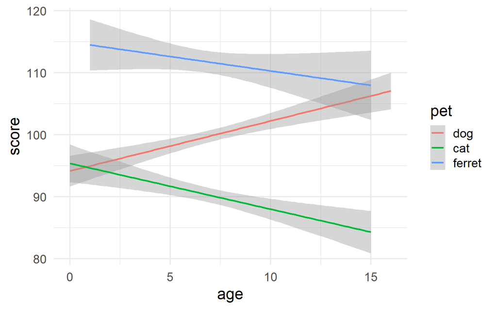

Minimal theme with 18-point base font size

```r
ggplot(pets, aes(age, score, color = pet)) +
  geom_smooth(formula = y ~ x, method="lm") +
  theme_minimal(base_size = 18)
```

It’s more complicated, but you can fully customise your theme with `theme()`. You can save this to an object and add it to the end of all of your plots to make the style consistent. Alternatively, you can set the theme at the top of a script with `theme_set()` and this will apply to all subsequent ggplot plots.

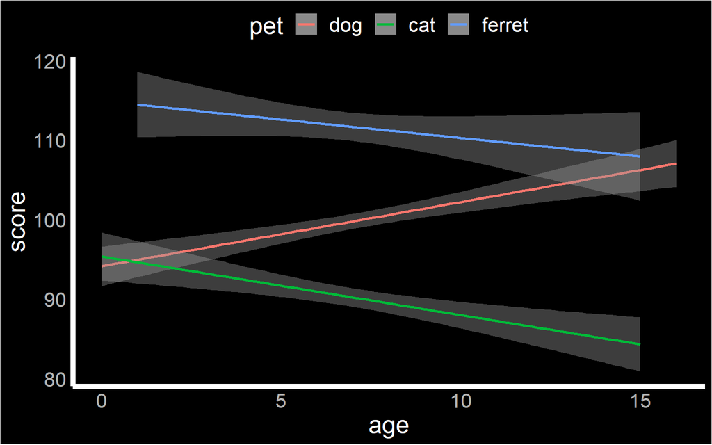

Custom theme

```r
# always start with a base theme that is closest to your desired theme
vampire_theme <- theme_dark() +
  theme(
    rect = element_rect(fill = "black"),
    panel.background = element_rect(fill = "black"),
    text = element_text(size = 20, colour = "white"),
    axis.text = element_text(size = 16, colour = "grey70"),
    line = element_line(colour = "white", size = 2),
    panel.grid = element_blank(),
    axis.line = element_line(colour = "white"),
    axis.ticks = element_blank(),
    legend.position = "top"
  )
theme_set(vampire_theme)
ggplot(pets, aes(age, score, color = pet)) +
  geom_smooth(formula = y ~ x, method="lm")
```

### Save as file

You can save a ggplot using `ggsave()`. It saves the last ggplot you made, by default, but you can specify which plot you want to save if you assigned that plot to a variable.

You can set the `width` and `height` of your plot. The default units are inches, but you can change the `units` argument to “in”, “cm”, or “mm”.

```r
box <- ggplot(pets, aes(pet, score, fill=pet)) +
  geom_boxplot(alpha = 0.5)
violin <- ggplot(pets, aes(pet, score, fill=pet)) +
  geom_violin(alpha = 0.5)
ggsave("demog_violin_plot.png", width = 5, height = 7)
ggsave("demog_box_plot.jpg", plot = box, width = 5, height = 7)
```

The file type is set from the filename suffix, or by specifying the argument `device`, which can take the following values: “eps”, “ps”, “tex”, “pdf”, “jpeg”, “tiff”, “png”, “bmp”, “svg” or “wmf”.

## Combination Plots

### Violinbox plot

A combination of a violin plot to show the shape of the distribution and a boxplot to show the median and interquartile ranges can be a very useful visualisation.

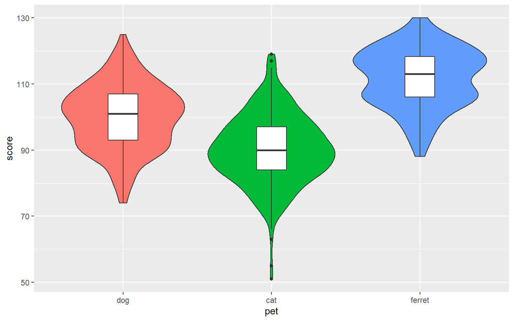

Violin-box plot

```r
ggplot(pets, aes(pet, score, fill = pet)) +
  geom_violin(show.legend = FALSE) +
  geom_boxplot(width = 0.2, fill = "white",
               show.legend = FALSE)
```

Set the `show.legend` argument to `FALSE` to hide the legend. We do this here because the x-axis already labels the pet types.

### Violin-jitter plot

If you don’t have a lot of data points, it’s good to represent them individually. You can use `geom_jitter` to do this.

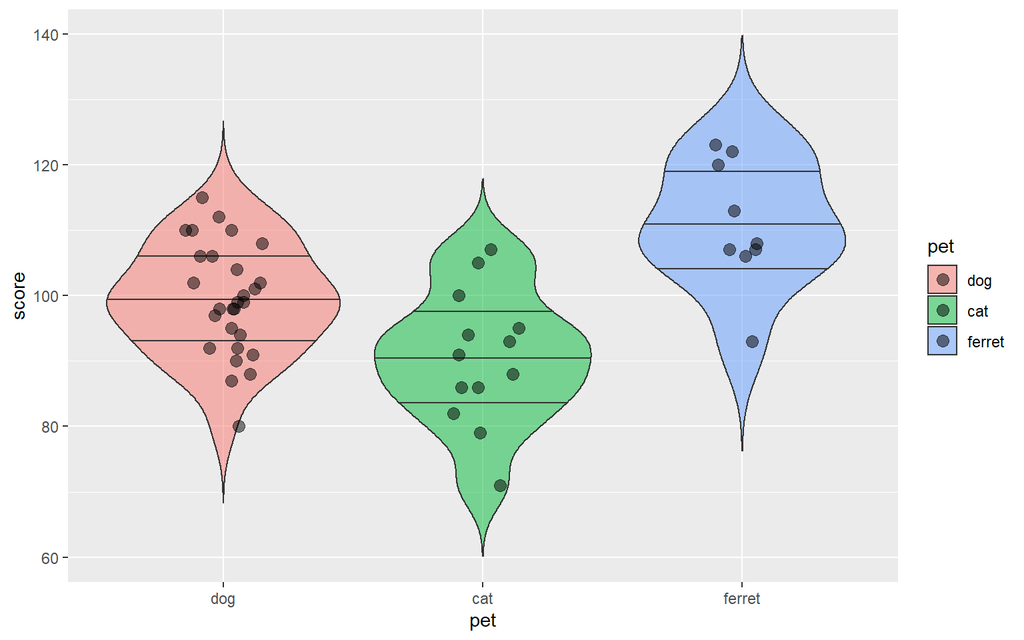

Violin-jitter plot

```r
# sample_n chooses 50 random observations from the dataset
ggplot(sample_n(pets, 50), aes(pet, score, fill=pet)) +
  geom_violin(
    trim = FALSE,
    draw_quantiles = c(0.25, 0.5, 0.75),
    alpha = 0.5
  ) +
  geom_jitter(
    width = 0.15, # points spread out over 15% of available width
    height = 0, # do not move position on the y-axis
    alpha = 0.5,
    size = 3
  )
```

### Grid of plots

You can use the [`patchwork`](https://patchwork.data-imaginist.com/) package to easily make grids of different graphs. First, you have to assign each plot a name.

```r
gg <- ggplot(pets, aes(pet, score, colour = pet))
nolegend <- theme(legend.position = 0)
vp <- gg + geom_violin(alpha = 0.5) + nolegend +
  ggtitle("Violin Plot")
bp <- gg + geom_boxplot(alpha = 0.5) + nolegend +
  ggtitle("Box Plot")
cp <- gg + stat_summary(fun = mean, geom = "col", fill = "white") + nolegend +
  ggtitle("Column Plot")
dp <- ggplot(pets, aes(score, colour = pet)) +
  geom_density() + nolegend +
  ggtitle("Density Plot")
```

Then you add all the plots together.

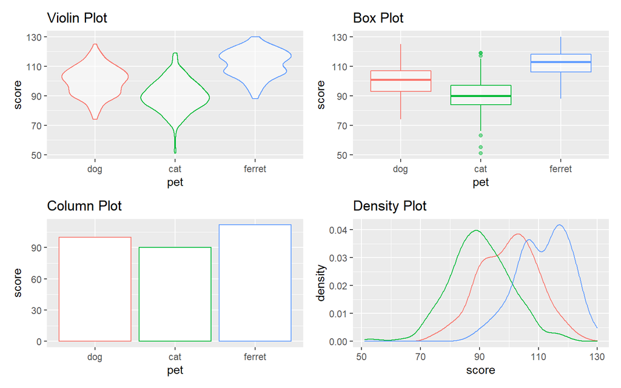

Default grid of plots

```r
vp + bp + cp + dp
```

You can use `+`, `|`, `/`, and parentheses to customise your layout.

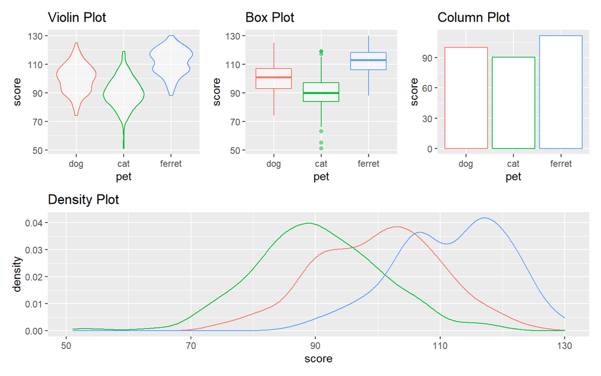

Custom plot layout.

```r
(vp | bp | cp) / dp
```

You can alter the plot layout to control the number and widths of plots per row or column, and add annotation.

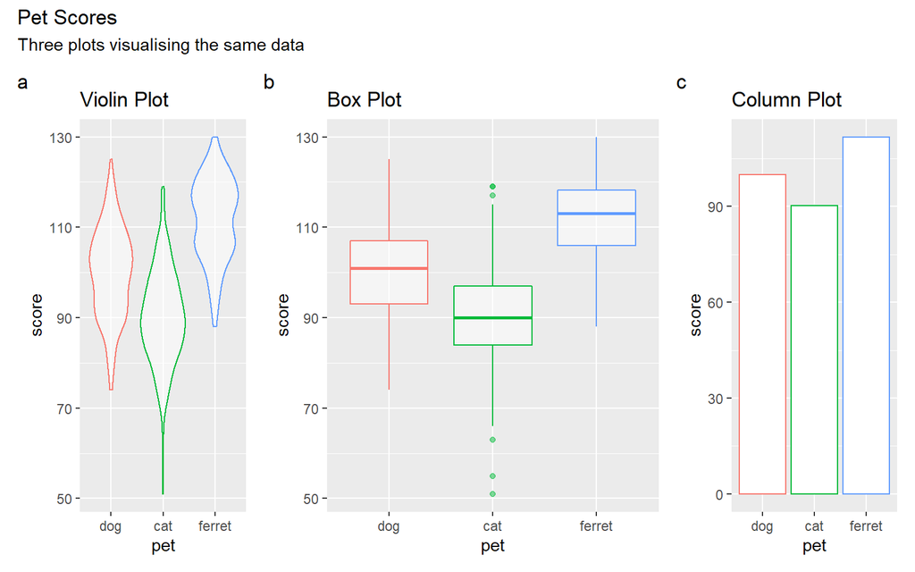

Plot annotation.

```r
vp + bp + cp +
  plot_layout(nrow = 1, width = c(1,2,1)) +
  plot_annotation(title = "Pet Scores",
                  subtitle = "Three plots visualising the same data",
                  tag_levels = "a")
```

Check the help for `plot_layout()` and plot_annotation()` to see what else you can do with them.

## Glossary

| term | definition |
| --- | --- |
| chunk | A section of code in an R Markdown file |
| continuous | Data that can take on any values between other existing values. |
| discrete | Data that can only take certain values, such as integers. |
| geom | The geometric style in which data are displayed, such as boxplot, density, or histogram. |
| likert | A rating scale with a small number of discrete points in order |
| nominal | Categorical variables that don't have an inherent order, such as types of animal. |
| ordinal | Discrete variables that have an inherent order, such as number of legs |

## Further Resources

- [ggplot2 cheat sheet](https://github.com/rstudio/cheatsheets/raw/master/data-visualization-2.1.pdf)
- [Chapter 28: Graphics for communication](http://r4ds.had.co.nz/graphics-for-communication.html) of *R for Data Science*
- [Look at Data](http://socviz.co/look-at-data.html) from [Data Vizualization for Social Science](http://socviz.co/)
- [The R Graph Gallery](http://www.r-graph-gallery.com/) (this is really useful)
- [R Graphics Cookbook](http://www.cookbook-r.com/Graphs/) by Winston Chang